# Class Demo 9-2 11am

Wells

9/2/2022

## Layout of Editor

1. Upper left: Text Editor
2. Lower left: Console
3. Upper Right: Environment
4. Lower Right: Files / Plots / Help

Just typing. This isn’t code.

1 + 2

```r
1 + 2
```

```
## [1] 3
```

## Coding Basic

create a vector

```r
v <- c(1, 4, 9, 16, 25)
```

operations on vectors

Take square root of every element of a vector

```r
sqrt(v)
```

```
## [1] 1 2 3 4 5
```

```r
v + 1
```

```
## [1]  2  5 10 17 26
```

A function applied to a vector applies the function to each element.

to update vector v (assign as the same name)

```r
v <- sqrt(v)
```

to undo, run the original function again:

```r
v <- c(1, 4, 9, 16, 25)
```

Usually good practice to give new names to new things:

```r
w <- sqrt(v)
```

Which elements of v are bigger than 10?

```r
v > 10
```

```
## [1] FALSE FALSE FALSE  TRUE  TRUE
```

Other operations: greater than or equal to >= Less than < Less than or equal to <= Equals == (two equal signs) Not equals !=

Create new vector of elements of logicals for if elements of v are > 10.

```r
u <- v > 10
```

How many elements are greater than 10?

2, just by counting

Ask R:

```r
sum(u)
```

```
## [1] 2
```

How do we write functions in R?

structure

```r
name_of_function <- function(variable1, variable6, pizza){
  variable1 + variable6*pizza
}
```

Recall the birthday problem. Suppose we have a group of k people and each chooses a number between 1 and n.

The probability of a match is

1 - n!/((n-k)!*n^k)

$$1 - \frac{n!}{(n-k)! n^k} = 1 - \binom{n}{k}\frac{k!}{n^k}$$

Write function to input n,k and return probability

```r
prob_bday_match <- function(n_bdays, k_people){
  1 - choose(n_bdays, k_people)*factorial(k_people)/(n_bdays^k_people)
}
```

How to plot in R (basic)?

To plot function of 1 variable:

1. need vector of inputs
2. need vector of corresponding outputs

View function at equally spaced points in domain

```r
n_bdays <- seq(from = 50, to = 1000, by = 25)
```

Evaluate function on n_bdays

```r
probs <- prob_bday_match(n_bdays, 25)
```

Use plot function applied to vectors of inputs and outputs

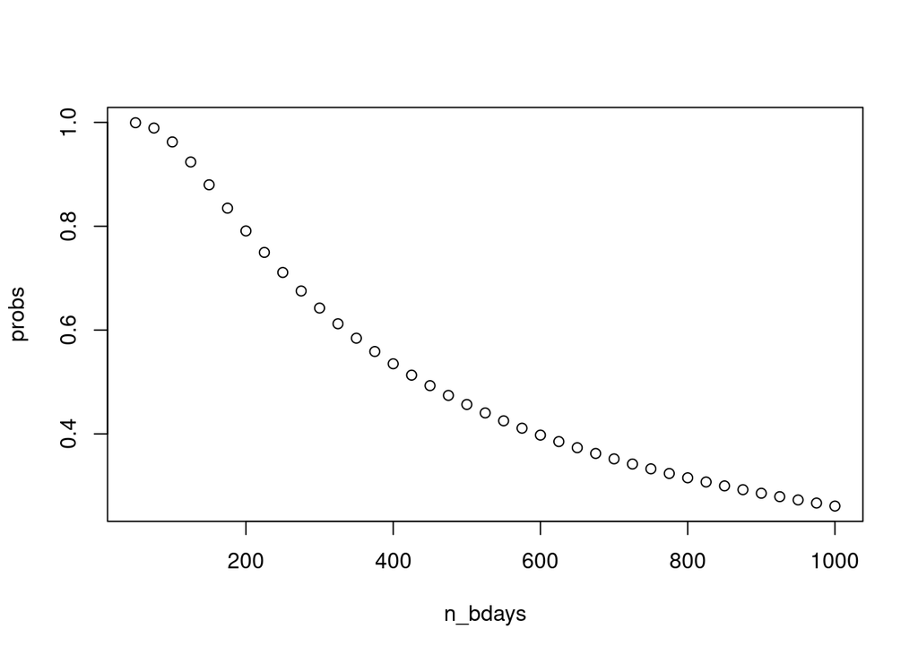

```r
plot(n_bdays, probs)
```